# Estimation of obesity levels based on eating habits and physical condition

link to the dataset and important information :

https://archive.ics.uci.edu/ml/datasets/Estimation+of+obesity+levels+based+on+eating+habits+and+physical+condition+#

sciencedirect.com/science/article/pii/S2352340919306985?via%3Dihub

"This dataset include data for the estimation of obesity levels in individuals from the countries of Mexico, Peru and Colombia, based on their eating habits and physical condition. The data contains 17 attributes and 2111 records, the records are labeled with the class variable NObesity (Obesity Level), that allows classification of the data using the values of Insufficient Weight, Normal Weight, Overweight Level I, Overweight Level II, Obesity Type I, Obesity Type II and Obesity Type III. 77% of the data was generated synthetically using the Weka tool and the SMOTE filter, 23% of the data was collected directly from users through a web platform."

## Packages

```python
import pandas as pd
import numpy as np
import sklearn as skl
from sklearn import preprocessing
from sklearn.model_selection import train_test_split
from sklearn.metrics import confusion_matrix
from sklearn.metrics import accuracy_score
import seaborn as sns
import matplotlib.pyplot as plt
import dash
import dash_core_components as dcc
import dash_html_components as html
from dash.dependencies import Input, Output, State
import statistics
from sklearn import preprocessing
from sklearn import svm
from sklearn.model_selection import StratifiedKFold,cross_val_score,RandomizedSearchCV,GridSearchCV
from sklearn.linear_model import LogisticRegression
from sklearn.ensemble import RandomForestClassifier,GradientBoostingClassifier
from sklearn.neighbors import KNeighborsClassifier
from sklearn.metrics import classification_report, confusion_matrix
from sklearn.naive_bayes import GaussianNB
from xgboost import XGBClassifier
import xgboost as xgb
```

## Variables

```python
#df = pd.read_csv('ObesityDataSet_raw_and_data_sinthetic.csv')
df= pd.read_csv("ObesityDataSet.csv")
```

### Description

```python
df.head()
```

|  | Gender | Age | Height | Weight | family_history_with_overweight | FAVC | FCVC | NCP | CAEC | SMOKE | CH2O | SCC | FAF | TUE | CALC | MTRANS | NObeyesdad |
| --- | --- | --- | --- | --- | --- | --- | --- | --- | --- | --- | --- | --- | --- | --- | --- | --- | --- |
| 0 | Female | 21.0 | 1.62 | 64.0 | yes | no | 2.0 | 3.0 | Sometimes | no | 2.0 | no | 0.0 | 1.0 | no | Public_Transportation | Normal_Weight |
| 1 | Female | 21.0 | 1.52 | 56.0 | yes | no | 3.0 | 3.0 | Sometimes | yes | 3.0 | yes | 3.0 | 0.0 | Sometimes | Public_Transportation | Normal_Weight |
| 2 | Male | 23.0 | 1.80 | 77.0 | yes | no | 2.0 | 3.0 | Sometimes | no | 2.0 | no | 2.0 | 1.0 | Frequently | Public_Transportation | Normal_Weight |
| 3 | Male | 27.0 | 1.80 | 87.0 | no | no | 3.0 | 3.0 | Sometimes | no | 2.0 | no | 2.0 | 0.0 | Frequently | Walking | Overweight_Level_I |
| 4 | Male | 22.0 | 1.78 | 89.8 | no | no | 2.0 | 1.0 | Sometimes | no | 2.0 | no | 0.0 | 0.0 | Sometimes | Public_Transportation | Overweight_Level_II |

- Gender
- Age
- Height
- Weight
- Family History with Overweight
- Attributes related with eating habits (6)
- Attributes related with the physical condition (4)

1 target:

- NObeyesdad, renamed NObesity

Another revelant information is that most of these variables are category, except for Age, Height and Weight.

### Problematic

Based on all the data, the objective of this project is to classify individuals according to their obesity level. This variables will be named: **NObesity**. This variable will take differents values among:

- Insufficient_Weight
- Normal_Weight
- Overweight_Level_I
- Overweight_Level_II
- Obesity_Type_I
- Obesity_Type_II
- Obesity_Type_III

## Data cleaning : part 1

We will perform data cleansing in two parts. In the first part we will process the data so that they are the most usable for graphic analysis. And in the second part we then transform the variables so that it is usable for the algorithm

### Missing values

First, let's drop all the row with missing value

```python
df_clean = df.dropna()
print(df_clean.shape, df.shape)
```

```
(2111, 17) (2111, 17)
```

We can see that they have the same shape, so there is no missing value: we keep **df** for our analyse

### Non-numeric values

```python
df.info()
```

```
<class 'pandas.core.frame.DataFrame'>
RangeIndex: 2111 entries, 0 to 2110
Data columns (total 17 columns):
 #   Column                          Non-Null Count  Dtype
---  ------                          --------------  -----
 0   Gender                          2111 non-null   object
 1   Age                             2111 non-null   float64
 2   Height                          2111 non-null   float64
 3   Weight                          2111 non-null   float64
 4   family_history_with_overweight  2111 non-null   object
 5   FAVC                            2111 non-null   object
 6   FCVC                            2111 non-null   float64
 7   NCP                             2111 non-null   float64
 8   CAEC                            2111 non-null   object
 9   SMOKE                           2111 non-null   object
 10  CH2O                            2111 non-null   float64
 11  SCC                             2111 non-null   object
 12  FAF                             2111 non-null   float64
 13  TUE                             2111 non-null   float64
 14  CALC                            2111 non-null   object
 15  MTRANS                          2111 non-null   object
 16  NObeyesdad                      2111 non-null   object
dtypes: float64(8), object(9)
memory usage: 280.5+ KB
```

### Outliers

For non-categorical variables, we need to check if there is any outliers. There 3 concerned variables are Age, Height and Weight.

Age is not a problem, because the study has been done with subjects between 14 and 61 years.

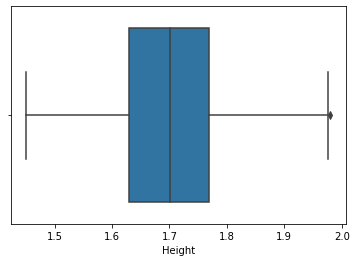

```python
sns.boxplot(x=df['Height'])
```

Only few point are outside the box for the Height

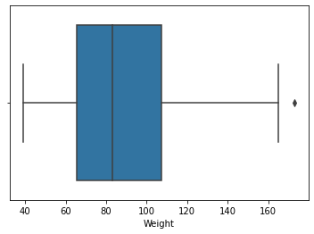

```python
sns.boxplot(x=df['Weight'])
```

Same for the Weight, we will exclude the extrem values. We set the terminales by using the quantiles values.

```python
df_categorized = df.copy()
```

```python
q1, q2 = df_categorized["Height"].quantile(q=0.25), df_categorized["Height"].quantile(q=0.75)
q3, q4 = df_categorized["Weight"].quantile(q=0.25), df_categorized["Weight"].quantile(q=0.75)

IQR1, IQR2 = q2-q1, q4-q3

#Height selection
df_categorized = df_categorized[df_categorized["Height"] >  q1 - 1.5*IQR1]
df_categorized = df_categorized[df_categorized["Height"] <  q2 + 1.5*IQR1]

#Weight selection
df_categorized = df_categorized[df_categorized["Weight"] >  q3 - 1.5*IQR2]
df_categorized = df_categorized[df_categorized["Weight"] <  q4 + 1.5*IQR2]

df_categorized.shape
```

```
(2109, 17)
```

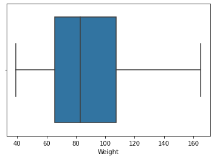

```python
sns.boxplot(x=df_categorized['Weight'])
```

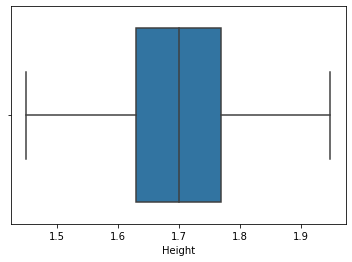

```python
sns.boxplot(x=df_categorized['Height'])
```

## Data Analysis

### Features

```python
df.describe().T.style.bar(subset=['mean'], color='#606ff2').background_gradient(subset=['std'], cmap='Blues').background_gradient(subset=['50%'], cmap='Blues')
```

|  | count | mean | std | min | 25% | 50% | 75% | max |
| --- | --- | --- | --- | --- | --- | --- | --- | --- |
| Age | 2111.000000 | 24.312600 | 6.345968 | 14.000000 | 19.947192 | 22.777890 | 26.000000 | 61.000000 |
| Height | 2111.000000 | 1.701677 | 0.093305 | 1.450000 | 1.630000 | 1.700499 | 1.768464 | 1.980000 |
| Weight | 2111.000000 | 86.586058 | 26.191172 | 39.000000 | 65.473343 | 83.000000 | 107.430682 | 173.000000 |
| FCVC | 2111.000000 | 2.419043 | 0.533927 | 1.000000 | 2.000000 | 2.385502 | 3.000000 | 3.000000 |
| NCP | 2111.000000 | 2.685628 | 0.778039 | 1.000000 | 2.658738 | 3.000000 | 3.000000 | 4.000000 |
| CH2O | 2111.000000 | 2.008011 | 0.612953 | 1.000000 | 1.584812 | 2.000000 | 2.477420 | 3.000000 |
| FAF | 2111.000000 | 1.010298 | 0.850592 | 0.000000 | 0.124505 | 1.000000 | 1.666678 | 3.000000 |
| TUE | 2111.000000 | 0.657866 | 0.608927 | 0.000000 | 0.000000 | 0.625350 | 1.000000 | 2.000000 |

```python
df_categorized["Weight_seg"] = pd.cut(df_categorized['Weight'], [0,40,50,60,70,80,90,100,110,120,130,140,150,160,df_categorized['Weight'].max()])
df_synth = pd.DataFrame(df_categorized.groupby(by = ["Weight_seg","NObeyesdad"])["Gender"].count().reset_index().rename(columns = {"Gender":"Percentage by type of Obesity"}))

pivot_weight = pd.pivot_table(data=df_synth,index=['NObeyesdad'], columns="Weight_seg")

for i in df_synth["NObeyesdad"].unique():
    pivot_weight.loc[i] = 100*pivot_weight.loc[i].values/pivot_weight.loc[i].values.sum()
pivot_weight.round(1)
```

| Weight_seg NObeyesdad | Percentage by type of Obesity (0.0, 40.0] | Percentage by type of Obesity (40.0, 50.0] | Percentage by type of Obesity (50.0, 60.0] | Percentage by type of Obesity (60.0, 70.0] | Percentage by type of Obesity (70.0, 80.0] | Percentage by type of Obesity (80.0, 90.0] | Percentage by type of Obesity (90.0, 100.0] | Percentage by type of Obesity (100.0, 110.0] | Percentage by type of Obesity (110.0, 120.0] | Percentage by type of Obesity (120.0, 130.0] | Percentage by type of Obesity (130.0, 140.0] | Percentage by type of Obesity (140.0, 150.0] | Percentage by type of Obesity (150.0, 160.0] | Percentage by type of Obesity (160.0, 165.057] |
| --- | --- | --- | --- | --- | --- | --- | --- | --- | --- | --- | --- | --- | --- | --- |
| Insufficient_Weight | 2.2 | 52.2 | 43.4 | 2.2 | 0.0 | 0.0 | 0.0 | 0.0 | 0.0 | 0.0 | 0.0 | 0.0 | 0.0 | 0.0 |
| Normal_Weight | 0.0 | 11.8 | 38.0 | 32.1 | 15.0 | 3.1 | 0.0 | 0.0 | 0.0 | 0.0 | 0.0 | 0.0 | 0.0 | 0.0 |
| Obesity_Type_I | 0.0 | 0.0 | 0.0 | 0.0 | 16.0 | 32.3 | 22.6 | 24.9 | 3.7 | 0.6 | 0.0 | 0.0 | 0.0 | 0.0 |
| Obesity_Type_II | 0.0 | 0.0 | 0.0 | 0.0 | 0.0 | 0.0 | 3.7 | 18.9 | 44.4 | 33.0 | 0.0 | 0.0 | 0.0 | 0.0 |
| Obesity_Type_III | 0.0 | 0.0 | 0.0 | 0.0 | 0.0 | 0.0 | 0.0 | 27.9 | 27.9 | 7.7 | 26.6 | 3.4 | 5.6 | 0.9 |
| Overweight_Level_I | 0.0 | 0.0 | 3.4 | 37.9 | 35.2 | 22.8 | 0.7 | 0.0 | 0.0 | 0.0 | 0.0 | 0.0 | 0.0 | 0.0 |
| Overweight_Level_II | 0.0 | 0.0 | 0.3 | 9.7 | 30.3 | 45.9 | 12.8 | 1.0 | 0.0 | 0.0 | 0.0 | 0.0 | 0.0 | 0.0 |

```python
df_categorized["Height_seg"] = pd.cut(df_categorized['Height'], [1.40,1.50,1.60,1.7,1.8,1.9,df_categorized['Height'].max()])
df_synth = pd.DataFrame(df_categorized.groupby(by = ["Height_seg","NObeyesdad"])["Gender"].count().reset_index().rename(columns = {"Gender":"Percentage by type of Obesity"}))

pivot_Height = pd.pivot_table(data=df_synth,index=['NObeyesdad'], columns="Height_seg")

for i in df_synth["NObeyesdad"].unique():
    pivot_Height.loc[i] = 100*pivot_Height.loc[i].values/pivot_Height.loc[i].values.sum()
pivot_Height.round(1)
```

| Height_seg NObeyesdad | Percentage by type of Obesity (1.4, 1.5] | Percentage by type of Obesity (1.5, 1.6] | Percentage by type of Obesity (1.6, 1.7] | Percentage by type of Obesity (1.7, 1.8] | Percentage by type of Obesity (1.8, 1.9] | Percentage by type of Obesity (1.9, 1.976] |
| --- | --- | --- | --- | --- | --- | --- |
| Insufficient_Weight | 0.0 | 26.5 | 21.7 | 38.2 | 13.6 | 0.0 |
| Normal_Weight | 2.4 | 24.7 | 39.7 | 23.0 | 9.4 | 0.7 |
| Obesity_Type_I | 0.3 | 18.9 | 35.7 | 31.1 | 12.6 | 1.4 |
| Obesity_Type_II | 0.0 | 0.3 | 15.8 | 53.2 | 26.3 | 4.4 |
| Obesity_Type_III | 0.0 | 3.1 | 56.3 | 33.4 | 7.1 | 0.0 |
| Overweight_Level_I | 2.1 | 14.5 | 37.6 | 29.7 | 16.2 | 0.0 |
| Overweight_Level_II | 2.8 | 11.0 | 33.4 | 40.7 | 10.7 | 1.4 |

As we can see, Weight has a huge impact on the classification: The majority of obese people are in the high weight ranges. For the Height, Obese people are on average taller than short people.

### Impact on target

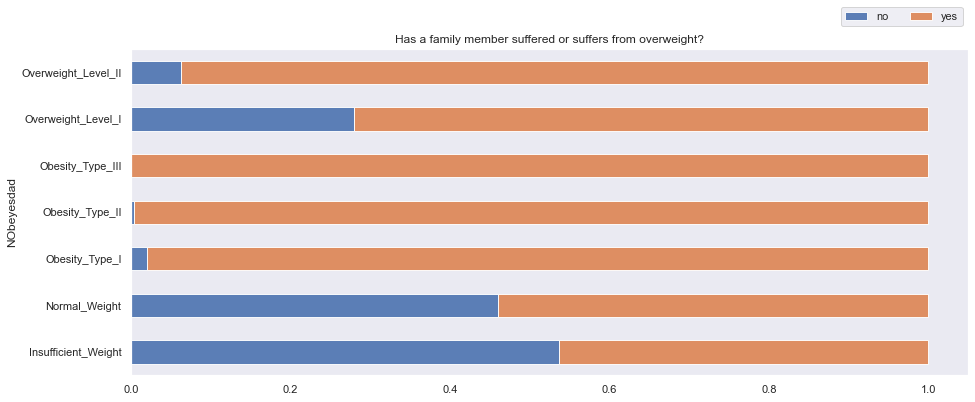

```python
big_count = pd.crosstab(df_categorized['NObeyesdad'], df_categorized['family_history_with_overweight'])
big_pct = big_count.div(big_count.sum(1), axis=0)
big_pct.plot.barh(stacked=True, figsize=(15, 6), alpha=0.9, grid=False)
plt.legend(loc="right", bbox_to_anchor=(1, 1.1), ncol=2)
plt.title("Has a family member suffered or suffers from overweight?")
```

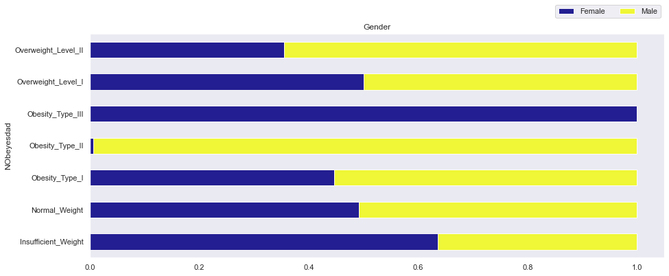

```python
big_count = pd.crosstab(df_categorized['NObeyesdad'], df_categorized['Gender'])
big_pct = big_count.div(big_count.sum(1), axis=0)
big_pct.plot.barh(stacked=True, figsize=(15, 6), alpha=0.9, grid=False, cmap='plasma')
plt.legend(loc="right", bbox_to_anchor=(1, 1.1), ncol=2)
plt.title("Gender")
```

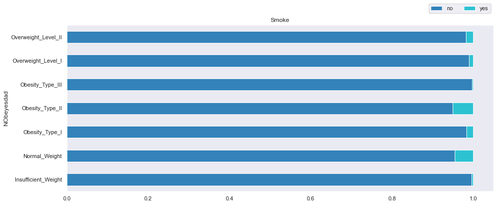

```python
big_count = pd.crosstab(df_categorized['NObeyesdad'], df_categorized['SMOKE'])
big_pct = big_count.div(big_count.sum(1), axis=0)
big_pct.plot.barh(stacked=True, figsize=(15, 6), alpha=0.9, grid=False, cmap = sns.color_palette('tab10', as_cmap= True))
plt.legend(loc="right", bbox_to_anchor=(1, 1.1), ncol=2)
plt.title("Smoke")
```

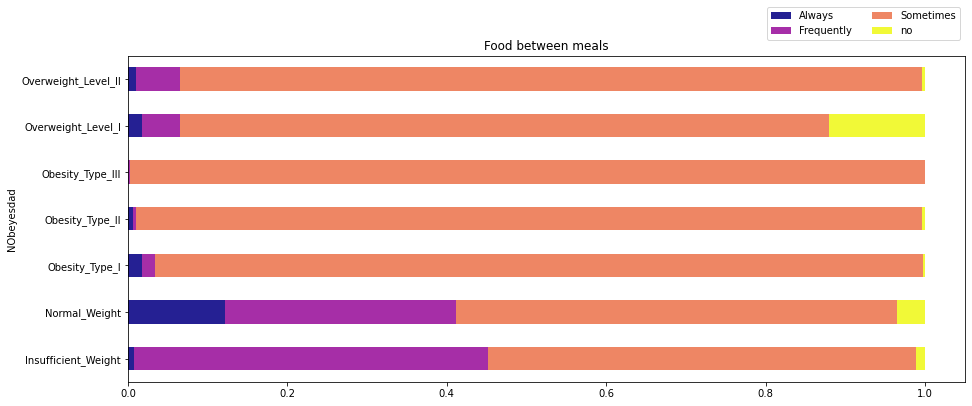

```python
big_count = pd.crosstab(df_categorized['NObeyesdad'], df_categorized['CAEC'])
big_pct = big_count.div(big_count.sum(1), axis=0)
big_pct.plot.barh(stacked=True, figsize=(15, 6), alpha=0.9, grid=False, cmap='plasma')
plt.legend(loc="right", bbox_to_anchor=(1, 1.1), ncol=2)
plt.title("Food between meals")
```

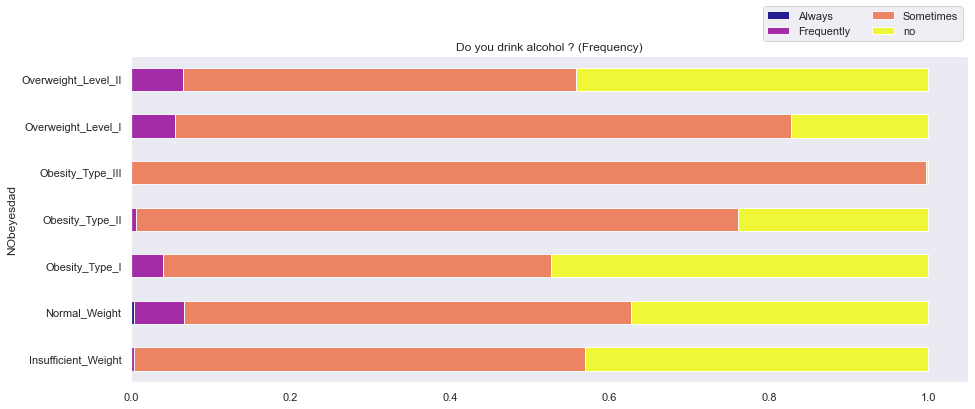

```python
big_count = pd.crosstab(df_categorized['NObeyesdad'], df_categorized['CALC'])
big_pct = big_count.div(big_count.sum(1), axis=0)
big_pct.plot.barh(stacked=True, figsize=(15, 6), alpha=0.9, grid=False, cmap='plasma')
plt.legend(loc="right", bbox_to_anchor=(1, 1.1), ncol=2)
plt.title("Do you drink alcohol ? (Frequency)")
```

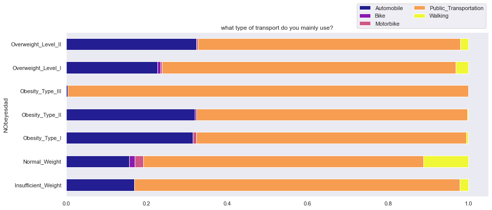

```python
big_count = pd.crosstab(df_categorized['NObeyesdad'], df_categorized['MTRANS'])
big_pct = big_count.div(big_count.sum(1), axis=0)
big_pct.plot.barh(stacked=True, figsize=(15, 6), alpha=0.9, grid=False, cmap='plasma')
plt.legend(loc="right", bbox_to_anchor=(1, 1.1), ncol=2)
plt.title("what type of transport do you mainly use?")
```

```python
def super_plot_for_WH(value, hue = 'NObeyesdad'):
    fig, ax = plt.subplots(1, 1, figsize=(30, 13))
    sns.histplot(x=value, hue=hue, data=df_categorized, kde=True, palette='rocket')
    ax.axvline(x=df_categorized[value].mean(), color='g', linestyle='--', linewidth=3)
    ax.text(df_categorized[value].mean(), df_categorized[value].mean(), "<--Mean", horizontalalignment='left', size='small', color='black', weight='semibold')
    if value=="Height":
        ax.set_xlim([1.45,1.95])
    elif value == 'Weight':
        ax.set_xlim([39,166])
    else :
        ax.set_xlim([14,62])

    sns.despine()
```

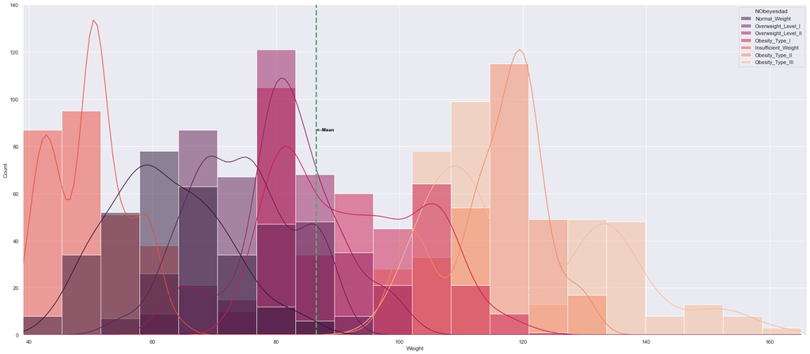

```python
super_plot_for_WH('Weight')
```

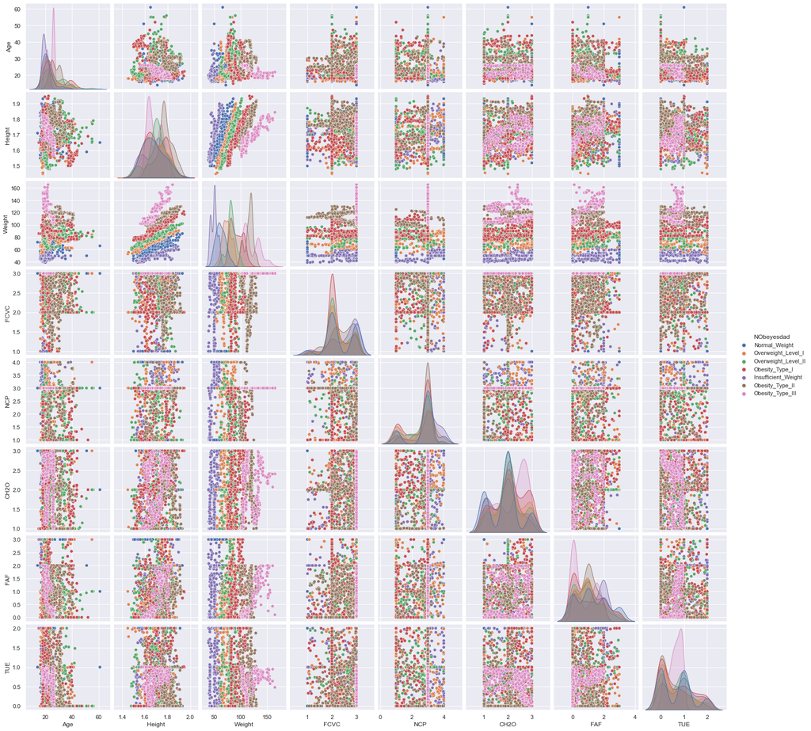

```python
sns.pairplot(df_categorized,hue='NObeyesdad')
```

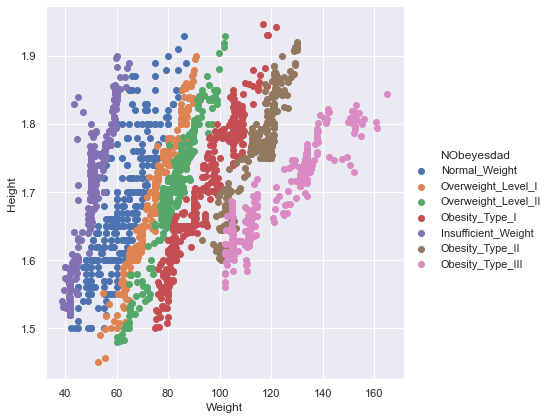

```python
sns.FacetGrid(df_categorized,hue="NObeyesdad",height=6).map(plt.scatter,"Weight","Height").add_legend()
```

### Target

```python
target = pd.DataFrame(df_categorized, columns = ['NObeyesdad'])
```

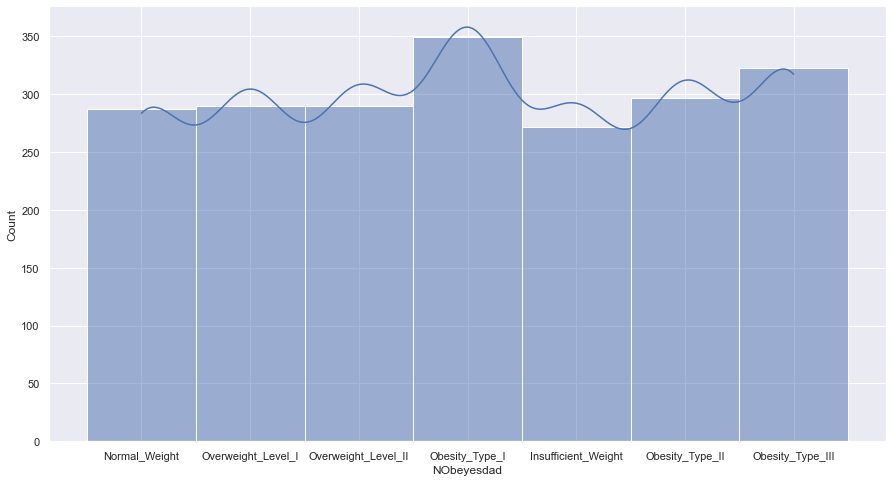

```python
sns.histplot(target['NObeyesdad'], kde=True)
sns.set(rc = {'figure.figsize':(15,15)})
```

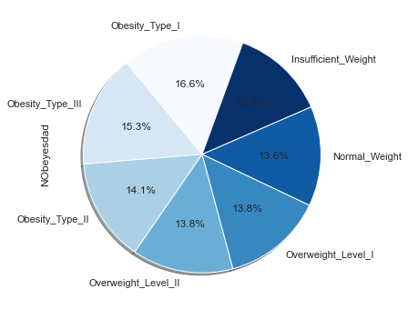

```python
fig, ax = plt.subplots(1, 1, figsize=(18, 6))
target['NObeyesdad'].value_counts().plot.pie(autopct='%1.1f%%',shadow=True, cmap="Blues", startangle=70)
```

The target variable is well balanced.

## Data cleaning : part 2

Now, we can convert all our string variables into numeric ones (through categories): Let's first check what are the different possibilities for each string variables (Gender, family_history_with_overweight, 'FAVC', CAEC, SMOKE, SCC, CALC, MTRANS, NObesitydad)

```python
list_var = ['Gender','family_history_with_overweight', 'FAVC', 'CAEC', 'SMOKE', 'SCC', 'CALC', 'MTRANS']
for x in list_var:
    print(df_categorized[x].unique())
```

```
['Female' 'Male']
['yes' 'no']
['no' 'yes']
['Sometimes' 'Frequently' 'Always' 'no']
['no' 'yes']
['no' 'yes']
['no' 'Sometimes' 'Frequently' 'Always']
['Public_Transportation' 'Walking' 'Automobile' 'Motorbike' 'Bike']
```

Create dictionnary with each string value and its numeric value

```python
dict_Gender = {'Female' : 0, 'Male' : 1}
dict_family_history_with_overweight = {'no' : 0, 'yes' : 1}
dict_FAVC = {'no' : 0, 'yes' : 1}
dict_CAEC = {'no' : 0, 'Sometimes' : 1, 'Frequently' : 2, 'Always' : 3}
dict_SMOKE = {'no' : 0, 'yes' : 1}
dict_SCC = {'no' : 0, 'yes' : 1}
dict_CALC = {'no' : 0, 'Sometimes' : 1, 'Frequently' : 2, 'Always' : 3}
dict_MTRANS = {'Public_Transportation' : 0, 'Walking' : 1, 'Automobile' : 2, 'Motorbike' : 3, 'Bike' : 4}
dict_NObeyesdad = {'Normal_Weight' : 0, 'Overweight_Level_I' : 1, 'Overweight_Level_II' : 2, 'Obesity_Type_I' : 3, 'Insufficient_Weight' : 4, 'Obesity_Type_II' : 5, 'Obesity_Type_III' : 6,}
```

```python
for x in list_var:
    exec("df_categorized['"+ x +"'] = df_categorized['"+ x +"'].replace(dict_"+ x +")") #transformation for each string variable

df_categorized.head()
```

|  | Gender | Age | Height | Weight | family_history_with_overweight | FAVC | FCVC | NCP | CAEC | SMOKE | CH2O | SCC | FAF | TUE | CALC | MTRANS | NObeyesdad |
| --- | --- | --- | --- | --- | --- | --- | --- | --- | --- | --- | --- | --- | --- | --- | --- | --- | --- |
| 0 | 0 | 21.0 | 1.62 | 64.0 | 1 | 0 | 2.0 | 3.0 | 1 | 0 | 2.0 | 0 | 0.0 | 1.0 | 0 | 0 | Normal_Weight |
| 1 | 0 | 21.0 | 1.52 | 56.0 | 1 | 0 | 3.0 | 3.0 | 1 | 1 | 3.0 | 1 | 3.0 | 0.0 | 1 | 0 | Normal_Weight |
| 2 | 1 | 23.0 | 1.80 | 77.0 | 1 | 0 | 2.0 | 3.0 | 1 | 0 | 2.0 | 0 | 2.0 | 1.0 | 2 | 0 | Normal_Weight |
| 3 | 1 | 27.0 | 1.80 | 87.0 | 0 | 0 | 3.0 | 3.0 | 1 | 0 | 2.0 | 0 | 2.0 | 0.0 | 2 | 1 | Overweight_Level_I |
| 4 | 1 | 22.0 | 1.78 | 89.8 | 0 | 0 | 2.0 | 1.0 | 1 | 0 | 2.0 | 0 | 0.0 | 0.0 | 1 | 0 | Overweight_Level_II |

As we can see, each string values have been convert into numeric value according to their refered dictionnary.

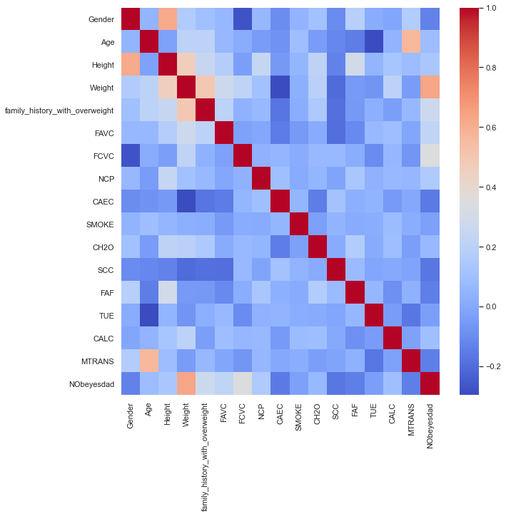

```python
dfbis = df_categorized
dfbis["NObeyesdad"] = dfbis["NObeyesdad"].replace(dict_NObeyesdad)
fig, ax = plt.subplots(figsize = (10,10))
sns.heatmap(dfbis.corr(), cmap = 'coolwarm')
```

We can see that every variable is globaly lineraly independant from each other. Because of that, ACP will not be efficient, so we do not perform it. We will select the variable correlated with less than 30%.

## Data Processing

### Data Normalisation

We perform a normalisation of the dataset, because some model will required the dataset to be formatted

```python
df_features = df_categorized.drop(columns = 'NObeyesdad')
```

```python
scaler = preprocessing.StandardScaler().fit(df_features)
df_scaled = pd.DataFrame(scaler.transform(df_features))
df_scaled['NObesity'] = df['NObeyesdad']
df_scaled.columns = df.columns.to_list()
df_scaled.head()
```

|  | Gender | Age | Height | Weight | family_history_with_overweight | FAVC | FCVC | NCP | CAEC | SMOKE | CH2O | SCC | FAF | TUE | CALC | MTRANS | NObeyesdad |
| --- | --- | --- | --- | --- | --- | --- | --- | --- | --- | --- | --- | --- | --- | --- | --- | --- | --- |
| 0 | -1.010491 | -0.523058 | -0.875632 | -0.862086 | 0.472702 | -2.75755 | -0.785139 | 0.404487 | -0.298887 | -0.146006 | -0.011550 | -0.218435 | -1.187188 | 0.562523 | -1.417696 | -0.563018 | Normal_Weight |
| 1 | -1.010491 | -0.523058 | -1.952200 | -1.168461 | 0.472702 | -2.75755 | 1.087963 | 0.404487 | -0.298887 | 6.849021 | 1.621152 | 4.578027 | 2.339294 | -1.079300 | 0.521631 | -0.563018 | Normal_Weight |
| 2 | 0.989617 | -0.207911 | 1.062191 | -0.364228 | 0.472702 | -2.75755 | -0.785139 | 0.404487 | -0.298887 | -0.146006 | -0.011550 | -0.218435 | 1.163800 | 0.562523 | 2.460958 | -0.563018 | Normal_Weight |
| 3 | 0.989617 | 0.422383 | 1.062191 | 0.018740 | -2.115496 | -2.75755 | 1.087963 | 0.404487 | -0.298887 | -0.146006 | -0.011550 | -0.218435 | 1.163800 | -1.079300 | 2.460958 | 0.588138 | Overweight_Level_I |
| 4 | 0.989617 | -0.365484 | 0.846877 | 0.125971 | -2.115496 | -2.75755 | -0.785139 | -2.165159 | -0.298887 | -0.146006 | -0.011550 | -0.218435 | -1.187188 | -1.079300 | 0.521631 | -0.563018 | Overweight_Level_II |

We now have our dataset scaled

## Modeling

```python
df_scaled_features = df_scaled.drop(columns = 'NObeyesdad')
```

### Training / Testing Sets

```python
X_train, X_test, Y_train, Y_test = train_test_split(df_scaled_features, df_scaled['NObeyesdad'], test_size=0.33)
```

We used the above method, but we cannot find the same data as when we developed the models. Since we had the best performances with the first sets we have tried, we decided to import them thanks to the csv that we had created at the time. But you can choose to use the sets from the above code. However, there is a 3% loss of accuracy on average. We are aware that this problem could have been fixed with rd.seed(32) but we did not think that our first set would have such a difference in performance with the other sets.

```python
X_train = pd.read_csv("X_train.csv")
Y_train = pd.read_csv("Y_train.csv")
X_test = pd.read_csv("X_test.csv")
Y_test = pd.read_csv("Y_test.csv")
Y_train = Y_train['NObeyesdad']
Y_test = Y_test['NObeyesdad']
```

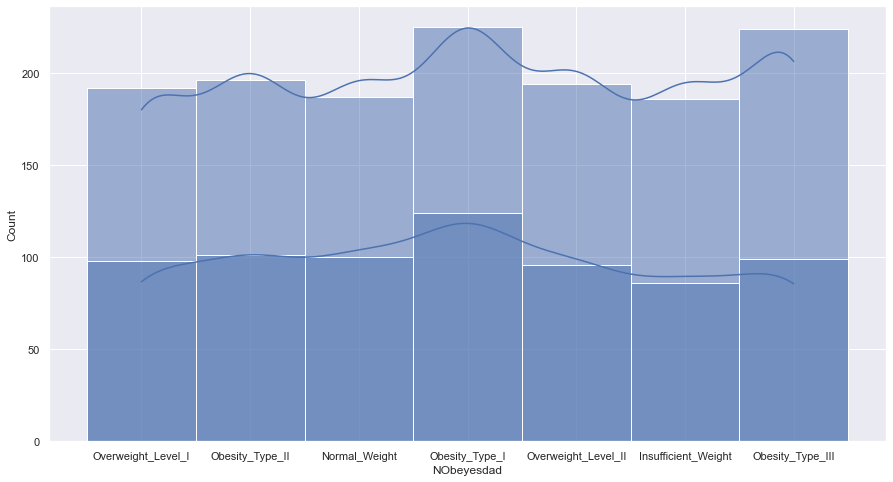

```python
sns.set(rc = {'figure.figsize':(15,8)})
sns.histplot(Y_train, kde=True)
sns.histplot(Y_test, kde=True)
```

The split is correct, because it is still well balanced.

## Model

These models and their performance will be classified and stock in the list "perf"

```python
perf=[]
```

### Logistic regression

```python
logisticRegr = LogisticRegression(solver='lbfgs', max_iter=1000)
logisticRegr.fit(X_train, Y_train)
y_pred = logisticRegr.predict(X_test)
```

```python
print("confusion matrix")
print(confusion_matrix(Y_test, y_pred))
print("model summary : ")
print(classification_report(Y_test, y_pred))
score = accuracy_score(Y_test, y_pred)
print("accuracy : "+str(score))
perf.append([score,"Logistic regression"])
```

```
confusion matrix
[[ 82   4   0   0   0   0   0]
 [  8  67   0   0   0  15  10]
 [  0   0 109   7   0   1   7]
 [  0   0   1 100   0   0   0]
 [  0   0   1   0  98   0   0]
 [  0   3   0   0   0  81  14]
 [  0   1  12   0   0  10  73]]
model summary :
                     precision    recall  f1-score   support

Insufficient_Weight       0.91      0.95      0.93        86
      Normal_Weight       0.89      0.67      0.77       100
     Obesity_Type_I       0.89      0.88      0.88       124
    Obesity_Type_II       0.93      0.99      0.96       101
   Obesity_Type_III       1.00      0.99      0.99        99
 Overweight_Level_I       0.76      0.83      0.79        98
Overweight_Level_II       0.70      0.76      0.73        96

           accuracy                           0.87       704
          macro avg       0.87      0.87      0.87       704
       weighted avg       0.87      0.87      0.87       704

accuracy : 0.8664772727272727
```

### Gradient Boosting Classifier

```python
gbdt = GradientBoostingClassifier(random_state=123)
gbdt.fit(X_train,Y_train)
gbdt_pre = gbdt.predict(X_test)
```

```python
print("confusion matrix")
print(confusion_matrix(Y_test, gbdt_pre))
print("model summary : ")
print(classification_report(Y_test, gbdt_pre))
score = accuracy_score(Y_test, gbdt_pre)
print("accuracy : "+str(score))
perf.append([score,"Gradient Boosting Classifier"])
```

```
confusion matrix
[[ 84   2   0   0   0   0   0]
 [  0  93   0   0   0   7   0]
 [  0   0 120   1   0   0   3]
 [  0   0   2  99   0   0   0]
 [  0   0   0   1  98   0   0]
 [  0   1   0   0   0  96   1]
 [  0   2   0   0   0   2  92]]
model summary :
                     precision    recall  f1-score   support

Insufficient_Weight       1.00      0.98      0.99        86
      Normal_Weight       0.95      0.93      0.94       100
     Obesity_Type_I       0.98      0.97      0.98       124
    Obesity_Type_II       0.98      0.98      0.98       101
   Obesity_Type_III       1.00      0.99      0.99        99
 Overweight_Level_I       0.91      0.98      0.95        98
Overweight_Level_II       0.96      0.96      0.96        96

           accuracy                           0.97       704
          macro avg       0.97      0.97      0.97       704
       weighted avg       0.97      0.97      0.97       704

accuracy : 0.96875
```

### KNN

```python
#function to determine the best possible k
stat=[]
k=[]
for i in range(2,20):#les k sont testé de 2 à 20 car il est très peu probable que k>20

    knn = KNeighborsClassifier(n_neighbors=i)
    knn.fit(X_train,Y_train)
    pred_knn = knn.predict(X_test)
    stat.append([accuracy_score(Y_test, pred_knn),i])
k=sorted(stat, reverse = True)
  #  print(k)

print(k)
```

```
[[0.8295454545454546, 2], [0.8196022727272727, 3], [0.796875, 5], [0.7911931818181818, 4], [0.78125, 6], [0.7784090909090909, 7], [0.7642045454545454, 9], [0.7642045454545454, 8], [0.7571022727272727, 12], [0.7556818181818182, 10], [0.7485795454545454, 11], [0.7471590909090909, 13], [0.7428977272727…
```

```python
#According to our last result k=2 is the best choice for our model
knn = KNeighborsClassifier(n_neighbors=2)
knn.fit(X_train,Y_train)
pred_knn = knn.predict(X_test)
```

```python
print("matrice de confusion")
print(confusion_matrix(Y_test, pred_knn))
print("model summary : ")
print(classification_report(Y_test, pred_knn))
score = accuracy_score(Y_test, pred_knn)
print("accuracy : "+str(score))
perf.append([score,"KNN"])
```

```
matrice de confusion
[[ 80   4   0   0   0   2   0]
 [ 31  47   3   1   0  10   8]
 [  1   1 112   4   0   3   3]
 [  0   0   3  98   0   0   0]
 [  0   1   0   0  97   1   0]
 [  2   6   7   1   0  80   2]
 [  2   6  10   2   0   6  70]]
model summary :
                     precision    recall  f1-score   support

Insufficient_Weight       0.69      0.93      0.79        86
      Normal_Weight       0.72      0.47      0.57       100
     Obesity_Type_I       0.83      0.90      0.86       124
    Obesity_Type_II       0.92      0.97      0.95       101
   Obesity_Type_III       1.00      0.98      0.99        99
 Overweight_Level_I       0.78      0.82      0.80        98
Overweight_Level_II       0.84      0.73      0.78        96

           accuracy                           0.83       704
          macro avg       0.83      0.83      0.82       704
       weighted avg       0.83      0.83      0.82       704

accuracy : 0.8295454545454546
```

### Support vector machine

```python
clf = svm.SVC()
clf.fit(X_train, Y_train)
pred_svm = clf.predict(X_test)
```

```python
scores=cross_val_score(clf,X_train,Y_train,n_jobs=-1)
print(scores)
print("%0.2f accuracy with a standard deviation of %0.2f" % (scores.mean(), scores.std()))
```

```
[0.84341637 0.87544484 0.85053381 0.86476868 0.83214286]
0.85 accuracy with a standard deviation of 0.02
```

```python
print("matrice de confusion")
print(confusion_matrix(Y_test,pred_svm))
print("model summary : ")
print(classification_report(Y_test,pred_svm))
score = accuracy_score(Y_test, pred_svm)
print("accuracy : "+str(score))
perf.append([score,"SVM"])
```

```
matrice de confusion
[[ 76  10   0   0   0   0   0]
 [  8  71   0   0   0  13   8]
 [  0   6 112   2   0   2   2]
 [  0   1   1  99   0   0   0]
 [  0   1   0   0  97   0   1]
 [  0  11   1   0   0  81   5]
 [  0   5   7   0   0   6  78]]
model summary :
                     precision    recall  f1-score   support

Insufficient_Weight       0.90      0.88      0.89        86
      Normal_Weight       0.68      0.71      0.69       100
     Obesity_Type_I       0.93      0.90      0.91       124
    Obesity_Type_II       0.98      0.98      0.98       101
   Obesity_Type_III       1.00      0.98      0.99        99
 Overweight_Level_I       0.79      0.83      0.81        98
Overweight_Level_II       0.83      0.81      0.82        96

           accuracy                           0.87       704
          macro avg       0.87      0.87      0.87       704
       weighted avg       0.87      0.87      0.87       704

accuracy : 0.8721590909090909
```

```python
parameters = {'C':[4,2,3,5,6], "degree":[1,3,5,2,4],'gamma':[0.5,0.1,0.15,0.6,0.8,0.9],"kernel":["rbf","poly","sigmoid"]}
grid=GridSearchCV(svm.SVC(),parameters,n_jobs=-1)
grid.fit(X_train,Y_train)
print(grid.best_score_,grid.best_estimator_)
```

```
0.9579613624809354 SVC(C=6, degree=1, gamma=0.9, kernel='poly')
```

```python
clf2 = svm.SVC(C=6, degree=1, gamma=0.9, kernel='poly')
clf2.fit(X_train, Y_train)
pred_svm2= clf2.predict(X_test)
```

```python
print("matrice de confusion")
print(confusion_matrix(Y_test,pred_svm2))
print("model summary : ")
print(classification_report(Y_test,pred_svm2))
score = accuracy_score(Y_test, pred_svm2)
print("accuracy : "+str(score))
perf.append([score,"SVM2"])
```

```
matrice de confusion
[[ 86   0   0   0   0   0   0]
 [  2  88   0   0   0  10   0]
 [  0   0 120   1   0   0   3]
 [  0   0   1 100   0   0   0]
 [  0   0   0   1  98   0   0]
 [  0   1   0   0   0  93   4]
 [  0   0   3   0   0   6  87]]
model summary :
                     precision    recall  f1-score   support

Insufficient_Weight       0.98      1.00      0.99        86
      Normal_Weight       0.99      0.88      0.93       100
     Obesity_Type_I       0.97      0.97      0.97       124
    Obesity_Type_II       0.98      0.99      0.99       101
   Obesity_Type_III       1.00      0.99      0.99        99
 Overweight_Level_I       0.85      0.95      0.90        98
Overweight_Level_II       0.93      0.91      0.92        96

           accuracy                           0.95       704
          macro avg       0.96      0.95      0.95       704
       weighted avg       0.96      0.95      0.95       704

accuracy : 0.9545454545454546
```

### Naive Bayes

```python
gnb = GaussianNB()
y_gnb = gnb.fit(X_train, Y_train).predict(X_test)
```

```python
print("matrice de confusion")
print(confusion_matrix(Y_test,y_gnb))
print("model summary : ")
print(classification_report(Y_test,y_gnb))
score = accuracy_score(Y_test, y_gnb)
print("accuracy : "+str(score))
perf.append([score,"Naive Bayes"])
```

```
matrice de confusion
[[ 85   1   0   0   0   0   0]
 [ 79   6   4   2   0   6   3]
 [  0   1  51  64   0   4   4]
 [  0   1   0 100   0   0   0]
 [  0   1   0   0  97   0   1]
 [ 39   0  31  21   0   7   0]
 [ 16   2  26  38   0   3  11]]
model summary :
                     precision    recall  f1-score   support

Insufficient_Weight       0.39      0.99      0.56        86
      Normal_Weight       0.50      0.06      0.11       100
     Obesity_Type_I       0.46      0.41      0.43       124
    Obesity_Type_II       0.44      0.99      0.61       101
   Obesity_Type_III       1.00      0.98      0.99        99
 Overweight_Level_I       0.35      0.07      0.12        98
Overweight_Level_II       0.58      0.11      0.19        96

           accuracy                           0.51       704
          macro avg       0.53      0.52      0.43       704
       weighted avg       0.53      0.51      0.43       704

accuracy : 0.5071022727272727
```

### Random Forest

```python
rf = RandomForestClassifier(n_estimators = 500)
rf.fit(X_train, Y_train)
rf_pred=rf.predict(X_test)
```

```python
print("matrice de confusion")
print(confusion_matrix(Y_test,rf_pred))
print("model summary : ")
print(classification_report(Y_test,rf_pred))
score = accuracy_score(Y_test, rf_pred)
print("accuracy : "+str(score))
perf.append([score,"Random Forest"])
```

```
matrice de confusion
[[ 80   6   0   0   0   0   0]
 [  0  88   0   0   0   8   4]
 [  0   1 118   0   0   1   4]
 [  0   0   1 100   0   0   0]
 [  0   0   0   0  99   0   0]
 [  0   5   0   0   0  91   2]
 [  0   4   1   0   0   3  88]]
model summary :
                     precision    recall  f1-score   support

Insufficient_Weight       1.00      0.93      0.96        86
      Normal_Weight       0.85      0.88      0.86       100
     Obesity_Type_I       0.98      0.95      0.97       124
    Obesity_Type_II       1.00      0.99      1.00       101
   Obesity_Type_III       1.00      1.00      1.00        99
 Overweight_Level_I       0.88      0.93      0.91        98
Overweight_Level_II       0.90      0.92      0.91        96

           accuracy                           0.94       704
          macro avg       0.94      0.94      0.94       704
       weighted avg       0.95      0.94      0.94       704

accuracy : 0.9431818181818182
```

### XGboost

```python
dict_NObeyesdad = {'Normal_Weight' : 0, 'Overweight_Level_I' : 1, 'Overweight_Level_II' : 2, 'Obesity_Type_I' : 3, 'Insufficient_Weight' : 4, 'Obesity_Type_II' : 5, 'Obesity_Type_III' : 6,}
Y_test_int=Y_test.replace(dict_NObeyesdad)
Y_train_int=Y_train.replace(dict_NObeyesdad)
```

```python
model = XGBClassifier()
model.fit(X_train, Y_train_int)
y_xgb=model.predict(X_test)
```

```
[21:26:10] WARNING: C:/Users/Administrator/workspace/xgboost-win64_release_1.5.1/src/learner.cc:1115: Starting in XGBoost 1.3.0, the default evaluation metric used with the objective 'multi:softprob' was changed from 'merror' to 'mlogloss'. Explicitly set eval_metric if you'd like to restore the old…
```

```python
print("matrice de confusion")
print(confusion_matrix(Y_test_int,y_xgb))
print("model summary : ")
print(classification_report(Y_test_int,y_xgb))
score = accuracy_score(Y_test_int, y_xgb)
print("accuracy : "+str(score))
perf.append([score,"XGBoost"])
```

```
matrice de confusion
[[ 87  12   1   0   0   0   0]
 [  2  95   1   0   0   0   0]
 [  3   1  89   3   0   0   0]
 [  0   0   2 122   0   0   0]
 [  2   0   0   0  84   0   0]
 [  0   0   0   1   0 100   0]
 [  0   0   0   0   0   1  98]]
model summary :
              precision    recall  f1-score   support

           0       0.93      0.87      0.90       100
           1       0.88      0.97      0.92        98
           2       0.96      0.93      0.94        96
           3       0.97      0.98      0.98       124
           4       1.00      0.98      0.99        86
           5       0.99      0.99      0.99       101
           6       1.00      0.99      0.99        99

    accuracy                           0.96       704
   macro avg       0.96      0.96      0.96       704
weighted avg       0.96      0.96      0.96       704

accuracy : 0.9588068181818182
```

```python
dtrain = xgb.DMatrix(X_train, label=Y_train_int)
dvalid = xgb.DMatrix(X_test, label=Y_test_int)
watchlist = [(dvalid, 'valid'), (dtrain, 'train')]
num_class=7
param = {'objective':'multi:softmax',
         'eta':'0.3', 'max_depth':10,
         'silent':1, 'nthread':-1,
         'num_class':num_class,
         'eval_metric':'merror'}
model = xgb.train(param, dtrain, 60, watchlist, early_stopping_rounds=20,
                  verbose_eval=10)
y_xgb2=model.predict(dvalid)
y_xgb2 = [int(x) for x in y_xgb2]
```

[output not shown]

```python
print("matrice de confusion")
print(confusion_matrix(Y_test_int,y_xgb2))
print("model summary : ")
print(classification_report(Y_test_int,y_xgb2))
score = accuracy_score(Y_test_int, y_xgb2)
print("accuracy : "+str(score))
perf.append([score,"XGBoost2"])
```

```
matrice de confusion
[[ 92   7   1   0   0   0   0]
 [  4  94   0   0   0   0   0]
 [  3   2  88   3   0   0   0]
 [  0   0   2 122   0   0   0]
 [  2   0   0   0  84   0   0]
 [  0   0   0   1   0 100   0]
 [  0   0   0   0   0   1  98]]
model summary :
              precision    recall  f1-score   support

           0       0.91      0.92      0.92       100
           1       0.91      0.96      0.94        98
           2       0.97      0.92      0.94        96
           3       0.97      0.98      0.98       124
           4       1.00      0.98      0.99        86
           5       0.99      0.99      0.99       101
           6       1.00      0.99      0.99        99

    accuracy                           0.96       704
   macro avg       0.96      0.96      0.96       704
weighted avg       0.96      0.96      0.96       704

accuracy : 0.9630681818181818
```

## Ranking of the best prediction models

```python
perf=sorted(perf, reverse = True)
for i in range(len(perf)):
    print(str(i+1)+"-" + str(perf[i][1])+" with an accuracy of :"+ str(round(perf[i][0]*100,2))+"%")
```

```
1-Gradient Boosting Classifier with an accuracy of :96.88%
2-XGBoost2 with an accuracy of :96.31%
3-XGBoost with an accuracy of :95.88%
4-SVM2 with an accuracy of :95.45%
5-Random Forest with an accuracy of :94.32%
6-SVM with an accuracy of :87.22%
7-SVM with an accuracy of :87.22%
8-Logistic regression with an accuracy of :86.65%
9-KNN with an accuracy of :82.95%
10-Naive Bayes with an accuracy of :50.71%
```

For our model and API we will use the gradient boosting classifier model because it is the one that has the best performance.

## Dash and API

After ranking the best algorithms, we now know that we must use gradient boosting. We have handed over all the lines of codes you need to launch the API. It may seem redundant with code segments that you may have seen before, but you just have to run this part there for the API to work (this was in case you were only running the API in our code). .

```python
#df = pd.read_csv('ObesityDataSet_raw_and_data_sinthetic.csv')
dt= pd.read_csv("ObesityDataSet.csv")
df= pd.read_csv("ObesityDataSet.csv")
dict_Gender = {'Female' : 0, 'Male' : 1}
dict_family_history_with_overweight = {'no' : 0, 'yes' : 1}
dict_FAVC = {'no' : 0, 'yes' : 1}
dict_CAEC = {'no' : 0, 'Sometimes' : 1, 'Frequently' : 2, 'Always' : 3}
dict_SMOKE = {'no' : 0, 'yes' : 1}
dict_SCC = {'no' : 0, 'yes' : 1}
dict_CALC = {'no' : 0, 'Sometimes' : 1, 'Frequently' : 2, 'Always' : 3}
dict_MTRANS = {'Public_Transportation' : 0, 'Walking' : 1, 'Automobile' : 2, 'Motorbike' : 3, 'Bike' : 4}
list_var = ['Gender','family_history_with_overweight', 'FAVC', 'CAEC', 'SMOKE', 'SCC', 'CALC', 'MTRANS']
for x in list_var:
    exec("dt['"+ x +"'] = dt['"+ x +"'].replace(dict_"+ x +")") #transformation for each string variable
dt = dt.drop(columns = 'NObeyesdad')
dt_col = dt.copy
```

```python
X_train = pd.read_csv("X_train.csv")
Y_train = pd.read_csv("Y_train.csv")
X_test = pd.read_csv("X_test.csv")
Y_test = pd.read_csv("Y_test.csv")
Y_train = Y_train['NObeyesdad']
Y_test = Y_test['NObeyesdad']
X = pd.concat([X_train,X_test], ignore_index=True)
Y = pd.concat([Y_train,Y_test], ignore_index=True)
```

```python
gbdt = GradientBoostingClassifier(random_state=123)
gbdt.fit(X,Y)
```

```
GradientBoostingClassifier(random_state=123)
```

```python
dict_Gender = {'Female' : 0, 'Male' : 1}
dict_family_history_with_overweight = {'no' : 0, 'yes' : 1}
dict_FAVC = {'no' : 0, 'yes' : 1}
dict_FCVC = {'Never' : 1, 'Sometimes' : 2, 'Always' : 3}
dict_CAEC = {'no' : 0, 'Sometimes' : 1, 'Frequently' : 2, 'Always' : 3}
dict_SMOKE = {'no' : 0, 'yes' : 1}
dict_SCC = {'no' : 0, 'yes' : 1}
dict_CALC = {'no' : 0, 'Sometimes' : 1, 'Frequently' : 2, 'Always' : 3}
dict_MTRANS = {'Public_Transportation' : 0, 'Walking' : 1, 'Automobile' : 2, 'Motorbike' : 3, 'Bike' : 4}
dict_NCP = {'Between 1 and 2' : 1, '3' : 3, 'more than 3' : 4}
dict_FAF = {'I do not have' : 0, '1 or 2 days' : 1, '2 or 4 days' : 2, '4 or 5 days' : 3}
dict_TUE = {'0–2 hours' : 0, '3–5 hours' : 1, 'More than 5 hours' : 2}
dict_CH2O = {'Less than a liter' : 0, 'Between 1 and 2 L' : 1, 'More than 2 L' : 2}

list_feat = ['Gender','family_history_with_overweight', 'FAVC','FCVC', 'CAEC', 'SMOKE', 'SCC', 'CALC', 'MTRANS', 'NCP','FAF','TUE','CH2O']
```

```python
def predict_value(n,selected_gender,selected_age,selected_height,selected_weight,selected_fam_hist,selected_favc,selected_fcvc,selected_ncp,selected_caec,selected_smoke,selected_ch2o,selected_scc,selected_faf,selected_tue,selected_calc,selected_mtrans):
    data = pd.DataFrame([[selected_gender,selected_age,selected_height,selected_weight,selected_fam_hist,selected_favc,selected_fcvc,selected_ncp,selected_caec,selected_smoke,selected_ch2o,selected_scc,selected_faf,selected_tue,selected_calc,selected_mtrans]])
    data.columns = dt.columns
    for x in list_feat:
        exec("data['"+ x +"'] = data['"+ x +"'].replace(dict_"+ x +")") #transformation for each string variable
    dataset = pd.concat([dt,data], ignore_index=True)
    scaler = preprocessing.StandardScaler().fit(dataset)
    dataset_scaled = pd.DataFrame(scaler.transform(dataset))
    dataset_scaled.columns = dt.columns.to_list()
    pred = gbdt.predict(dataset_scaled.tail(1))
    return pred[0]
```

```python
pred_value = ''

if __name__ == '__main__':

    app = dash.Dash(__name__)

    app.layout = html.Div(children=[
                            #Title
                            html.H1(
                                children='Health check',
                                className = 'header'
                            ),

                            #gender
                            html.Div(children =[
                                html.P(children = 'What is your gender ?'),

                                dcc.Input(
                                id = 'selected_gender',
                                type = 'text',
                                list = 'liste_gender',
                                placeholder = 'Gender',
                                debounce = False,
                                spellCheck = True,
                                ),
                            ]),

                            #age
                            html.Div(children =[
                                html.P(children = 'What is your age?'),

                                dcc.Input(
                                id = 'selected_age',
                                type = 'text',
                                placeholder = 'Age',
                                debounce = False,
                                spellCheck = True,
                                inputMode = 'numeric'
                                ),
                            ]),

                            #height
                            html.Div(children =[
                                html.P(children = 'What is your height?'),

                                dcc.Input(
                                id = 'selected_height',
                                type = 'text',
                                placeholder = 'Height (meter)',
                                debounce = False,
                                spellCheck = True,
                                inputMode = 'numeric'
                                ),
                            ]),

                            #weight
                            html.Div(children =[
                                html.P(children = 'What is your weight?'),

                                dcc.Input(
                                id = 'selected_weight',
                                type = 'text',
                                placeholder = 'Weight (kg)',
                                debounce = False,
                                spellCheck = True,
                                inputMode = 'numeric'
                                ),
                            ]),

                            #family overweight
                            html.Div(children =[
                                html.P(children = 'Has a family member suffered or suffers from overweight?'),

                                dcc.Input(
                                id = 'selected_fam_hist',
                                type = 'text',
                                list = 'liste_family_history',
                                placeholder = 'Family history with overweight',
                                debounce = False,
                                spellCheck = True,
                                ),
                            ]),

                            #facv
                            html.Div(children =[
                                html.P(children = 'Do you eat high caloric food frequently?'),

                                dcc.Input(
                                id = 'selected_favc',
                                type = 'text',
                                list = 'liste_favc',
                                placeholder = 'Consumption of high caloric food',
                                debounce = False,
                                spellCheck = True,
                                ),
                            ]),

                            #fccv
                            html.Div(children =[
                                html.P(children = 'Do you usually eat vegetables in your meals?'),

                                dcc.Input(
                                id = 'selected_fcvc',
                                type = 'text',
                                list = 'liste_fcvc',
                                placeholder = 'Frequency of consumption of vegetables',
                                debounce = False,
                                spellCheck = True,
                                inputMode = 'numeric'
                                ),
                            ]),

                            #ncp
                            html.Div(children =[
                                html.P(children = 'How many main meals do you have daily?'),

                                dcc.Input(
                                id = 'selected_ncp',
                                type = 'text',
                                list = 'liste_ncp',
                                placeholder = 'Number of main meals',
                                debounce = False,
                                spellCheck = True
                                ),
                            ]),

                            #caec
                            html.Div(children =[
                                html.P(children = 'Do you eat any food between meals?'),

                                dcc.Input(
                                id = 'selected_caec',
                                type = 'text',
                                list = 'liste_caec',
                                placeholder = 'Consumption of food between meals',
                                debounce = False,
                                spellCheck = True,
                                ),
                            ]),

                            #smoke
                            html.Div(children =[
                                html.P(children = 'Do you smoke?'),
```

```python
                                dcc.Input(
                                id = 'selected_smoke',
                                type = 'text',
                                list = 'liste_smoke',
                                placeholder = 'Smoker',
                                debounce = False,
                                spellCheck = True,
                                ),
                            ]),

                            #water
                            html.Div(children =[
                                html.P(children = 'How much water do you drink daily?'),

                                dcc.Input(
                                id = 'selected_ch2o',
                                type = 'text',
                                list = 'liste_ch2o',
                                placeholder = 'Consumption of water daily',
                                debounce = False,
                                spellCheck = True,
                                inputMode = 'numeric'
                                ),
                            ]),

                            #calories monitoring
                            html.Div(children =[
                                html.P(children = 'Do you monitor the calories you eat daily?'),

                                dcc.Input(
                                id = 'selected_scc',
                                type = 'text',
                                list = 'liste_scc',
                                placeholder = 'Calories consumption monitoring',
                                debounce = False,
                                spellCheck = True,
                                ),
                            ]),

                            #physical activities
                            html.Div(children =[
                                html.P(children = 'How often do you have physical activity?'),

                                dcc.Input(
                                id = 'selected_faf',
                                type = 'text',
                                list = 'liste_faf',
                                placeholder = 'Physical activity frequency',
                                debounce = False,
                                spellCheck = True,
                                inputMode = 'numeric'
                                ),
                            ]),

                            #technologie usage
                            html.Div(children =[
                                html.P(children = 'How much time do you use technological devices such as cell phone, videogames, television, computer and others?'),

                                dcc.Input(
                                id = 'selected_tue',
                                type = 'text',
                                list = 'liste_tue',
                                placeholder = 'Time using technology devices',
                                debounce = False,
                                spellCheck = True,
                                inputMode = 'numeric'
                                ),
                            ]),



                            #alcohol
                            html.Div(children =[
                                html.P(children = 'how often do you drink alcohol?'),

                                dcc.Input(
                                id = 'selected_calc',
                                type = 'text',
                                list = 'liste_calc',
                                placeholder = 'Consumption of alcohol',
                                debounce = False,
                                spellCheck = True,
                                ),
                            ]),

                            #transport mode
                            html.Div(children =[
                                html.P(children = 'Which transportation do you usually use?'),

                                dcc.Input(
                                id = 'selected_mtrans',
                                type = 'text',
                                list = 'liste_mtrans',
                                placeholder = 'Transportation used',
                                debounce = False,
                                spellCheck = True,
                                ),
                            ]),

                            #list Tool
                            html.Div(children = [
                                #Gender
                                html.Datalist(
                                        id = 'liste_gender',
                                        children = [
                                        html.Option(value = x) for x in df['Gender'].unique()]
                                    ),

                                #Family history
                                html.Datalist(
                                        id = 'liste_family_history',
                                        children = [
                                        html.Option(value = x) for x in df['family_history_with_overweight'].unique()]
                                    ),

                                #FAVC
                                html.Datalist(
                                        id = 'liste_favc',
                                        children = [
                                        html.Option(value = x) for x in df['FAVC'].unique()]
                                    ),

                                #CAEC
                                html.Datalist(
                                        id = 'liste_caec',
                                        children = [
                                        html.Option(value = x) for x in df['CAEC'].unique()]
                                    ),

                                #SMOKE
                                html.Datalist(
                                        id = 'liste_smoke',
                                        children = [
                                        html.Option(value = x) for x in df['SMOKE'].unique()]
                                    ),
```

```python
                                #SCC
                                html.Datalist(
                                        id = 'liste_scc',
                                        children = [
                                        html.Option(value = x) for x in df['SCC'].unique()]
                                    ),

                                #CALC
                                html.Datalist(
                                        id = 'liste_calc',
                                        children = [
                                        html.Option(value = x) for x in df['CALC'].unique()]
                                    ),

                                #MTRANS
                                html.Datalist(
                                        id = 'liste_mtrans',
                                        children = [
                                        html.Option(value = x) for x in df['MTRANS'].unique()]
                                    ),

                                html.Datalist(
                                        id = 'liste_ncp',
                                        children = [
                                        html.Option(value = 'Between 1 and 2'),
                                        html.Option(value = '3'),
                                        html.Option(value = 'more than 3')]
                                    ),

                                html.Datalist(
                                        id = 'liste_faf',
                                        children = [
                                        html.Option(value = 'I do not have'),
                                        html.Option(value = '1 or 2 days'),
                                        html.Option(value = '2 or 4 days'),
                                        html.Option(value = '4 or 5 days')]
                                    ),
                                html.Datalist(
                                        id = 'liste_tue',
                                        children = [
                                        html.Option(value = '0–2 hours'),
                                        html.Option(value = '3–5 hours'),
                                        html.Option(value = 'More than 5 hours')]
                                    ),

                                html.Datalist(
                                        id = 'liste_ch2o',
                                        children = [
                                        html.Option(value = 'Less than a liter'),
                                        html.Option(value = 'Between 1 and 2 L'),
                                        html.Option(value = 'More than 2 L')]
                                    ),

                                html.Datalist(
                                        id = 'liste_fcvc',
                                        children = [
                                        html.Option(value = 'Never'),
                                        html.Option(value = 'Sometimes'),
                                        html.Option(value = 'Always')]
                                    )

                                ]),
                            html.Button(
                                id='calcul_button',
                                n_clicks=0,
                                children='Calculate'
                            ),

                            html.Div(children =[
                                html.H3(children = 'Estimation of overweigth:'),
                                html.P(
                                    id = 'prediction',
                                    children = pred_value
                                )
                            ])
    ]
    )

    @app.callback(
    Output('prediction', 'children'),

    Input('calcul_button', 'n_clicks'),
    State('selected_gender', 'value'),
    State('selected_age', 'value'),
    State('selected_height', 'value'),
    State('selected_weight', 'value'),
    State('selected_fam_hist', 'value'),
    State('selected_favc', 'value'),
    State('selected_fcvc', 'value'),
    State('selected_ncp', 'value'),
    State('selected_caec', 'value'),
    State('selected_smoke', 'value'),
    State('selected_ch2o', 'value'),
    State('selected_scc', 'value'),
    State('selected_faf', 'value'),
    State('selected_tue', 'value'),
    State('selected_calc', 'value'),
    State('selected_mtrans', 'value')
    )

    def predict(n_clicks,selected_gender,selected_age,selected_height,selected_weight,selected_fam_hist,selected_favc,selected_fcvc,selected_ncp,selected_caec,selected_smoke,selected_ch2o,selected_scc,selected_faf,selected_tue,selected_calc,selected_mtrans):
        pred_value = predict_value(n_clicks,selected_gender,selected_age,selected_height,selected_weight,selected_fam_hist,selected_favc,selected_fcvc,selected_ncp,selected_caec,selected_smoke,selected_ch2o,selected_scc,selected_faf,selected_tue,selected_calc,selected_mtrans)
        return pred_value

    app.run_server(debug = False)
```

```
Dash is running on http://127.0.0.1:8050/

 * Serving Flask app "__main__" (lazy loading)
 * Environment: production
   WARNING: This is a development server. Do not use it in a production deployment.
   Use a production WSGI server instead.
 * Debug mode: off
```

```
 * Running on http://127.0.0.1:8050/ (Press CTRL+C to quit)
```